# FDR

# A simple example when there IS signal

What if we sampled

- 10 observations from a normal(mean=**0**,sd=1.0) distribution
- 10 observations from a normal(mean=**1.5**,sd=1.0)

Would a t-test be able to detect a significant difference between the two?

# A simple example when there IS signal

```r
x1 = rnorm(n=10, m=0, sd=1)
x2 = rnorm(n=10, m=1.5, sd=1)

print(x1)
```

```
##  [1]  0.8844253  0.4363136  0.2165772 -0.4442567  2.2172460  1.6540163
##  [7] -0.6253514 -0.2821897  1.5465244 -0.5495090
```

```r
print(x2)
```

```
##  [1] 1.6421945 0.7093148 0.3699020 0.7792011 2.2405223 2.5365065 0.6654740
##  [8] 2.0012060 1.2724855 0.8368065
```

# A simple example when there IS signal

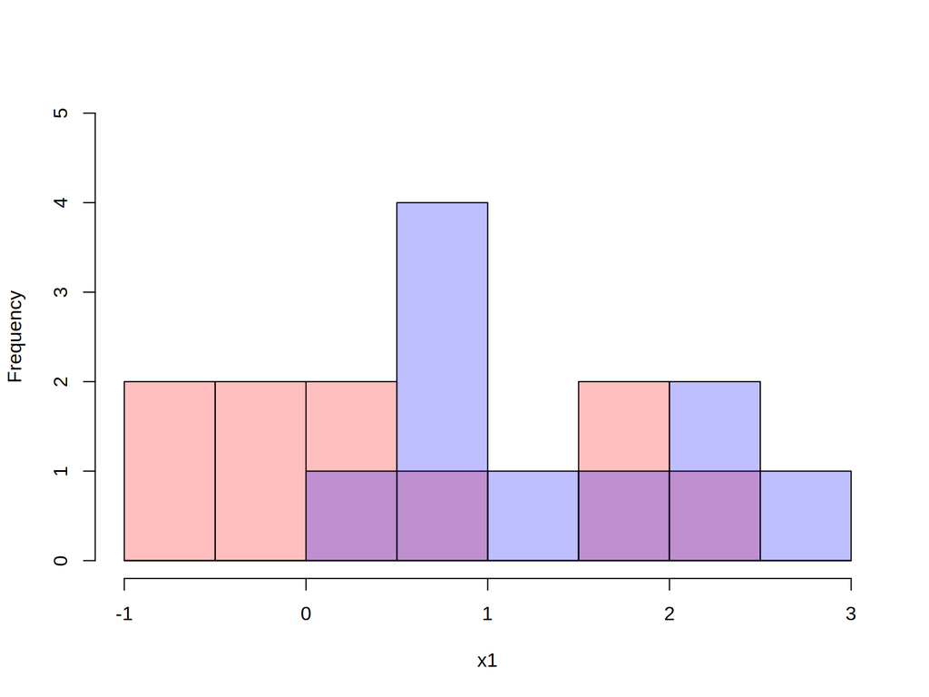

```r
#use h0 to get the proper range
h0 = hist(c(x1, x2), breaks=10, plot=F)
h1 = hist(x1, breaks=h0$breaks, plot=F)
h2 = hist(x2, breaks=h0$breaks, plot=F)
plot(h1, col=rgb(1, 0, 0, .25), ylim=c(0, max(h0$counts)), main="")
plot(h2, col=rgb(0, 0, 1, .25), add=T)
```

# A simple example when there IS signal

```r
  res = t.test(x1, x2)
  print(res)
```

```
##
##  Welch Two Sample t-test
##
## data:  x1 and x2
## t = -1.9859, df = 16.531, p-value = 0.06388
## alternative hypothesis: true difference in means is not equal to 0
## 95 percent confidence interval:
##  -1.65171459  0.05175109
## sample estimates:
## mean of x mean of y
## 0.5053796 1.3053613
```

# A simple example when there IS signal

What if we did this 1000 times?

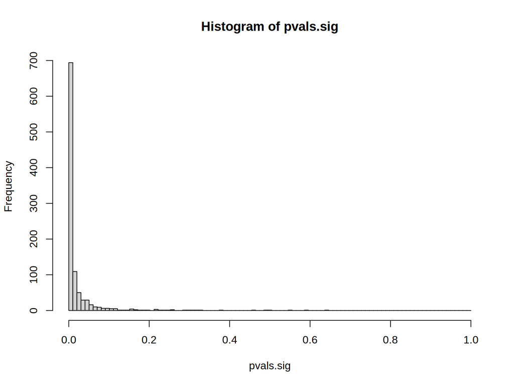

```r
  testSignal = function(...){
    x1 = rnorm(n=10, m=0, sd=1)
    x2 = rnorm(n=10, m=1.5, sd=1)
    res = t.test(x1, x2)
    res$p.value
  }

  N=1000
  pvals.sig = sapply(1:N, testSignal)
  hist(pvals.sig, breaks = seq(0,1, length=100))
```

```r
  #how many results have a pval < 0.05?
  sum(pvals.sig < 0.05)
```

```
## [1] 911
```

# A simple example when there IS signal

Out of 1000 tests we successfully rejected the null 911 times (true positives). A pretty powerful test and we found many significant results.

# A simple example when there is NO signal

This time we sample

- 10 obs from a Normal(mu=0,sd=1.0)
- 10 obs from a Normal(mu=0,sd=1.0)

Both samples come from the same distribution. Will a t-test give us a significant p-value?

```r
    x1 = rnorm(n=10, m=0, sd=1)
    x2 = rnorm(n=10, m=0, sd=1)
    res = t.test(x1, x2)
    print(res)
```

```
##
##  Welch Two Sample t-test
##
## data:  x1 and x2
## t = 0.38702, df = 17.252, p-value = 0.7035
## alternative hypothesis: true difference in means is not equal to 0
## 95 percent confidence interval:
##  -0.8660204  1.2556534
## sample estimates:
##   mean of x   mean of y
## -0.07962758 -0.27444410
```

# A simple example when there is NO signal

What if we repeated it 1000 times?

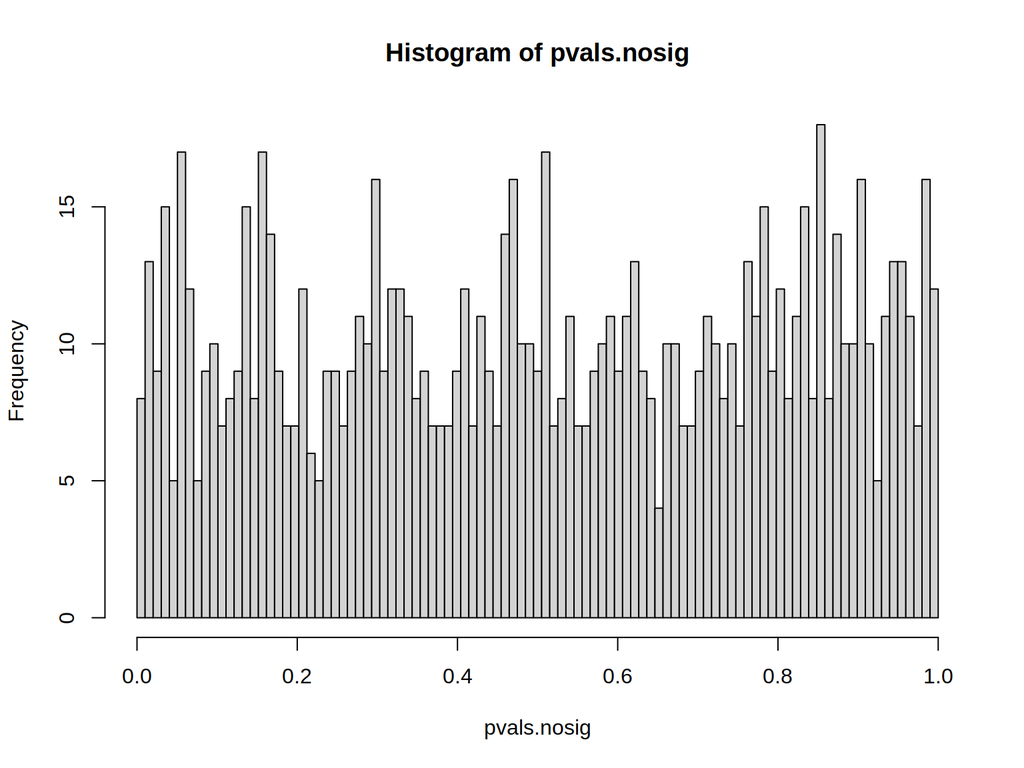

```r
  testNoSignal = function(...){
    x1 = rnorm(n=10, m=0, sd=1)
    x2 = rnorm(n=10, m=0, sd=1)
    res = t.test(x1, x2)
    res$p.value
  }
  pvals.nosig = sapply(1:N, testNoSignal)
  hist(pvals.nosig, breaks = seq(0,1, length=100))
```

```r
  #how many results have a pval < 0.05?
  n1 = sum(pvals.nosig < 0.05)
  print(n1)
```

```
## [1] 50
```

# A simple example when there is NO signal

This time there are 50 tests where the null was incorrectly rejected (false positives). 50 out of 1000 is 5%, which is pretty much what we expect when we choose a significance level(alpha) of 0.05.

# a simple example with both

In the real world, we don’t know which datasets have signal and which do not. When going through results we want a selection criteria that minimizes the false positives, but is also able to find real signal. If we set our alpha too low (bonferroni) we’ll miss out on a lot of the interesting results. If we don’t do anything, we’ll be dealing with a lot of garbage. FDR is a good compromise.

# a simple example with both

Let’s look at the histogram of the pvals when we mix the two datasets together.

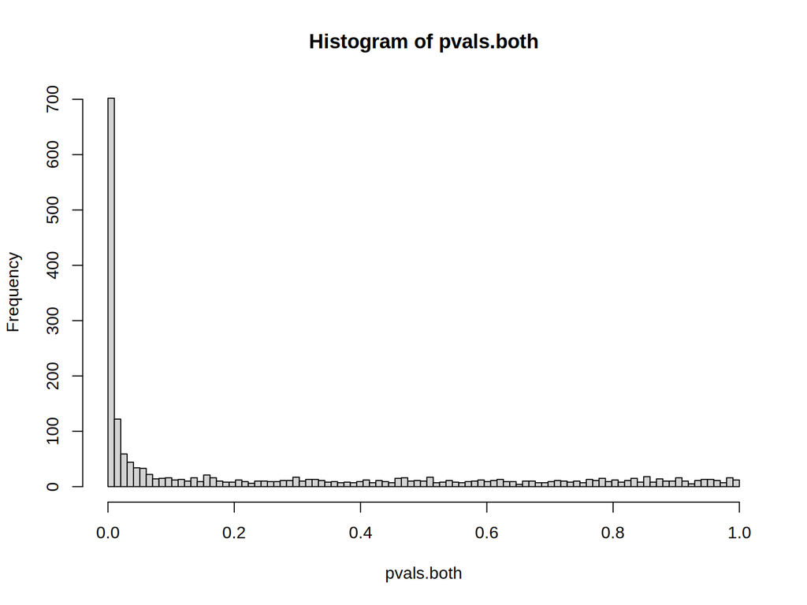

```r
  pvals.both = c(pvals.sig, pvals.nosig)
  hist(pvals.both, breaks=seq(0, 1, length=100))
```

# a simple example with both

if we do nothing, and just select the results with an unadjusted pval < 0.05, we’ll wind up with 961 positive results.

- true positives: 911
- false positives: 50

# a simple example with both

if we use bonferonni, and just select the results with an unadjusted pval < 0.05/1000 = 0.00005, we’ll wind up with 67 positive results.

- true positives: 67
- false positives: 0

# a simple example with both

if we use FDR and select those with an adjusted qval < 0.05, we’ll wind up with 827 positive results.

- true positives: 806
- false positives: 21

# a simple example with both

In ‘omics’ studies, and most studies in general, the signal we’re trying to find makes up a very small portion of the dataset we’re searching through. what happens when the ratio of signal/nosignal changes?

```r
#return the numbers of true/false positives when selecting from
#unadjusted, bonferroni, FDR
checkSignificance = function(N1 = 1000, N2 = 10000, alpha=0.05){
  pvals.sig = sapply(1:N1, testSignal)
  pvals.nosig = sapply(1:N2, testNoSignal)
  pvals.both = c(pvals.sig, pvals.nosig)
  qvals.both = p.adjust(pvals.both, method="fdr")

  c(
    N1=N1, N2=N2,
    TP.unadj=sum(pvals.sig < alpha),
    FP.unadj=sum(pvals.nosig < alpha),
    TP.bn=sum(pvals.sig < alpha/(N1+N2)),
    FP.bn=sum(pvals.nosig < alpha/(N1+N2)),
    TP.fdr=sum(qvals.both[1:N1] < alpha),
    FP.fdr=sum(qvals.both[-(1:N1)] < alpha)
  )
}
```

# a simple example with both

```r
  rbind(
    checkSignificance(1000, 1000, 0.05),
    checkSignificance(1000, 5000, 0.05),
    checkSignificance(1000, 10000, 0.05),
    checkSignificance(1000, 20000, 0.05)
  )
```

```
##        N1    N2 TP.unadj FP.unadj TP.bn FP.bn TP.fdr FP.fdr
## [1,] 1000  1000      887       49    49     0    767     14
## [2,] 1000  5000      908      246    22     0    588     23
## [3,] 1000 10000      858      478    10     0    400     18
## [4,] 1000 20000      867      937     6     0    243      4
```